# myc-tagged HEATR3 CoIP

Version 1.0 (31 May 2017)

## Where to find the slides

1. Clone project from [GitHub link](https://github.com/mevers/MS_CoIP)
2. Install necessary R library dependencies

   ```
   source("http://www.bioconductor.org/biocLite.R");
   biocLite(c("readxl", "ggplot2", "ggrepel", "reshape2", "GGally", "DT"));
   ```

3. Download and install [RStudio](https://www.rstudio.com/)
4. Open `slides.Rmd` in RStudio and execute `Run Presentation`

## MS data

We load unprocessed data from the original Excel sheets and merge all data sets into one dataframe.

| proteinID | GFP_Exp2_sample_1 | MT_Exp2_sample_1 | GFP_Exp2_sample_2 | MT_Exp2_sample_2 | GFP_Exp3 | MT_Exp3 | GFP_Exp4 | MT_Exp4 |
| --- | --- | --- | --- | --- | --- | --- | --- | --- |
| CON__ENSEMBL:ENSBTAP00000018574 |  | 1584900 |  |  |  |  |  |  |
| CON__ENSEMBL:ENSBTAP00000024466;CON__ENSEMBL:ENSBTAP00000024462 |  |  |  |  |  |  |  | 13528000 |
| CON__ENSEMBL:ENSBTAP00000038253 |  |  |  |  |  |  |  |  |
| CON__ENSEMBL:ENSP00000377550;sp\|P13646\|K1C13_HUMANKeratin,typeIcytoskeletal13OS=HomosapiensGN=KRT13PE=1SV=4;CON__P13646-1 | 7646700 |  |  |  |  |  |  |  |
| CON__P00711;sp\|LALBA_BOVIN\| |  |  |  |  |  |  |  | 20803000 |
| CON__P01966;sp\|HBA_HUMAN\|;sp\|P69905\|HBA_HUMANHemoglobinsubunitalphaOS=HomosapiensGN=HBA1PE=1SV=2;sp\|P02008\|HBAZ_HUMANHemoglobinsubunitzetaOS=HomosapiensGN=HBZPE=1SV=2 |  | 3745000 |  |  |  |  |  |  |
| CON__P02535-1 | 1703600 |  |  |  |  |  |  |  |
| CON__P02662;sp\|CAS1_BOVIN\| | 142050000 | 49699000 | 24834000 | 54937000 | 6485700 | 153840000 | 2325900000 | 3762000000 |
| CON__P02663;sp\|CAS2_BOVIN\| | 48372000 | 29858000 |  | 11232000 | 5340400 | 165680000 | 1275100000 | 3616700000 |
| CON__P02666;sp\|CASB_BOVIN\| | 41727000 | 22619000 | 10446000 | 16397000 | 5111000 | 150160000 | 2674500000 | 2379200000 |

[output cut: 1561 more lines]

## Replicate library consistency

We plot pairwise sample log2-transformed LFQ values, and show corresponding Pearson's product-moment correlation coefficients. Congruence between replicate libraries is reflected by large positive correlation coefficients. Dashed red lines indicate the identity map, and blue lines with blue shaded areas give the linear model fit including 95% confidence intervals. We highlight HEATR3 abundances in red.

## GFP libraries

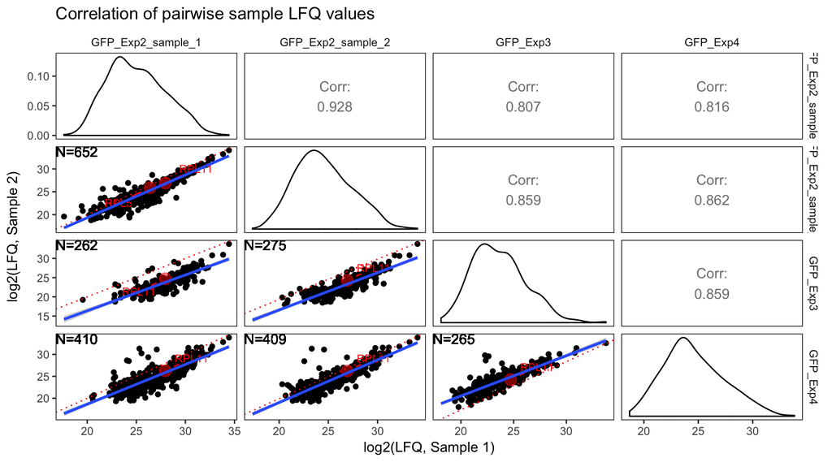

## MT libraries

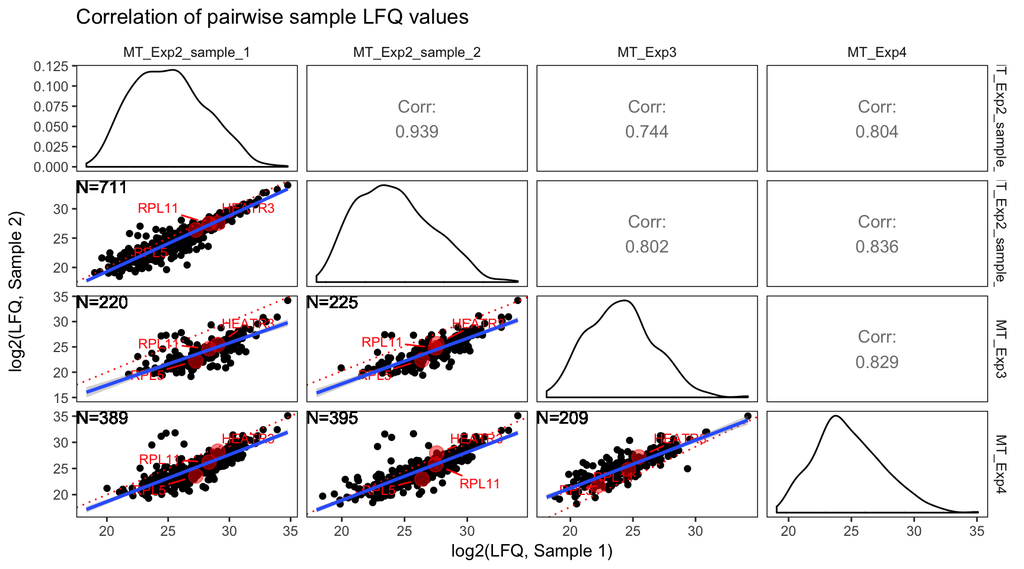

## All libraries

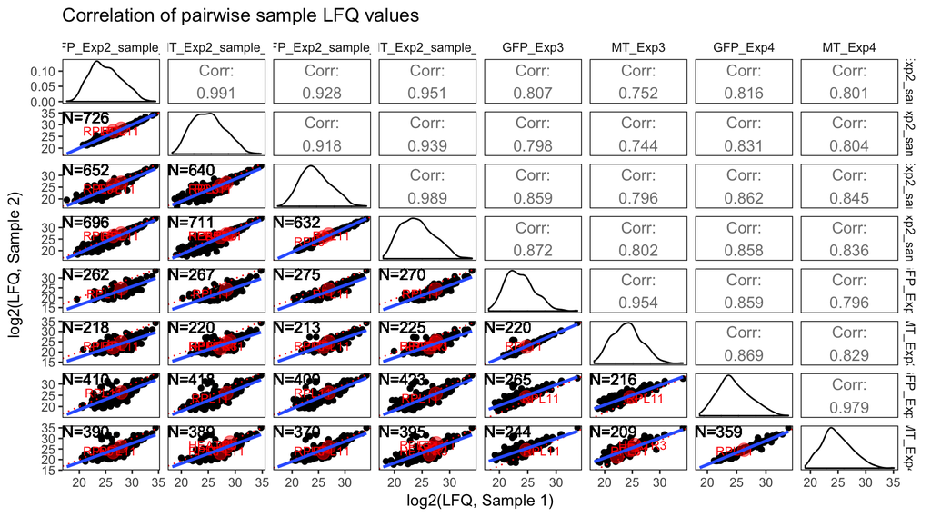

## Principle component analysis I

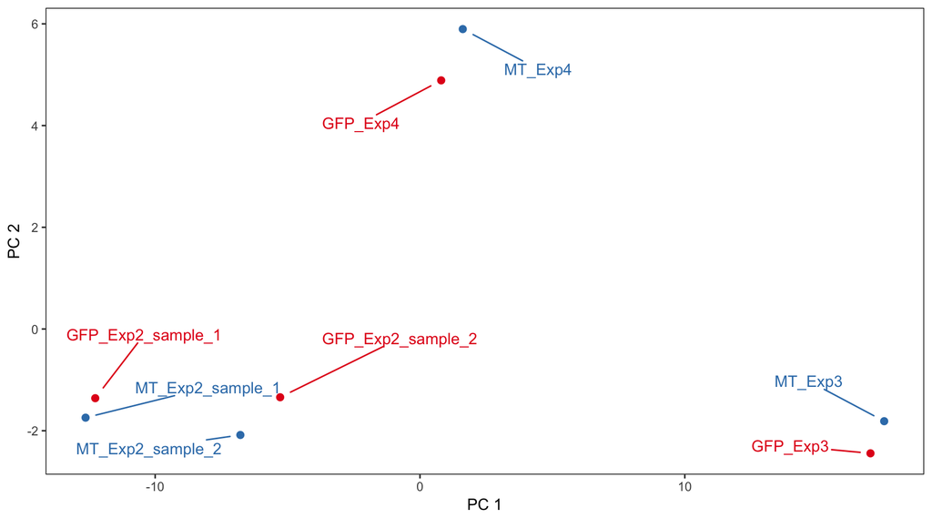

## Principle component analysis II

It is clear from the figure that the main separation in principle components of the libraries is driven by the different replicate experiments **irrespective** of the condition (overexpressed myc-tagged HEATR3 vs. GFP control). In other words, **the differences between e.g. the myc-tagged Exp3 and myc-tagged Exp4 libraries are larger than the differences between the myc-tagged Exp3 and GFP control Exp3 libraries**.

## GFP-corrected replicate library consistency I

We calculate relative protein abundances as \[ \text{relLog2LFQ} = \log_2(\text{LFQ, MT}) - \log_2(\text{LFQ, GFP})\,, \] and show pairwise comparisons.

## GFP-corrected replicate library consistency II

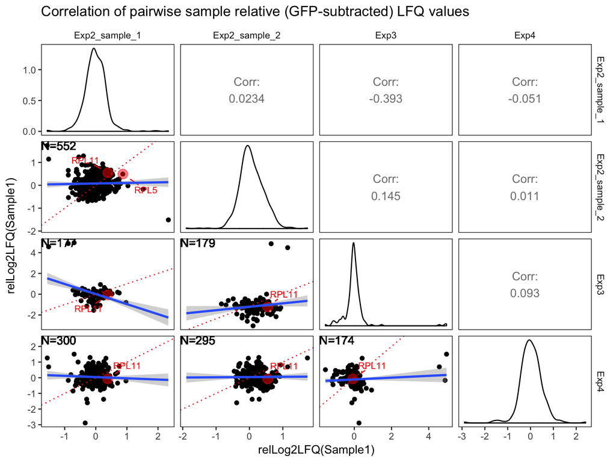

## Discussion & results

Pairwise comparisons of protein abundances in the myc-tagged and GFP libraries show large congruence within myc-tagged replicates and within GFP libraries. However, the large correlation coefficients between protein abundances from myc-tagged with GFP control libraries suggest that specific binding using the myc antibodies is low.

The principle component analysis supports this conclusion, where the separation in PC1 is driven by the different replicate experiments rather than the condition.

Surprisingly, myc-tagged and GFP control libraries resemble replicate libraries, in as much as the by-design replicates behave as replicate libraries.